# Statistik für Biologie FS 2026

# Deviations from Normailty

## QQ Plots and Transformations

We investigate the ratio of biomass between marine reserves and non-reserve control areas.

```r
marine <- read_csv("~/Dropbox/Teaching/BlogdownPages/StatisticsForBiology/ABD_all_data/chapter13/chap13e1MarineReserve.csv")
head(marine)
```

```
## # A tibble: 6 × 1
##   biomassRatio
##          <dbl>
## 1         1.34
## 2         1.96
## 3         2.49
## 4         1.27
## 5         1.19
## 6         1.15
```

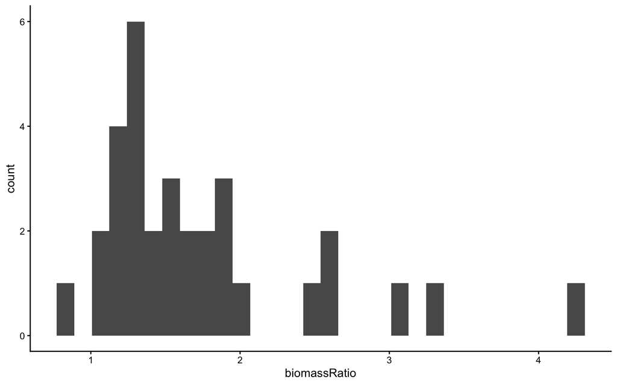

```r
ggplot(data = marine) +
  geom_histogram(mapping = aes(x = biomassRatio))
```

Normal quantile plot of biomass ratio data.

```r
library(car)
```

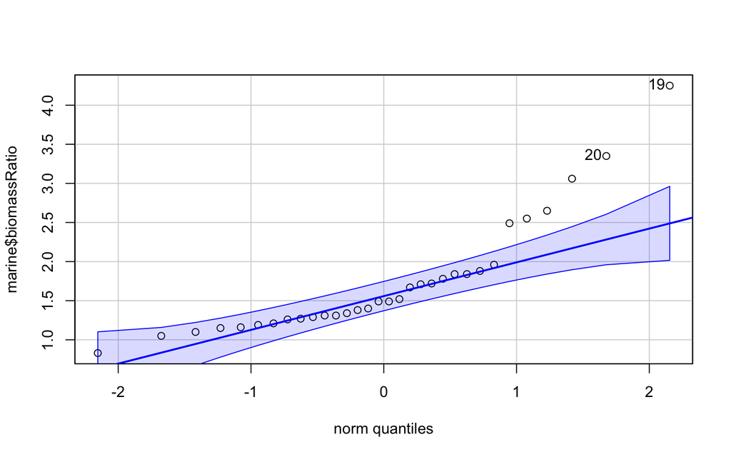

```
## [1] 19 20
```

```r
qqPlot(marine$biomassRatio, distribution = "norm")
```

The function log() takes the natural logarithm of all the elements of a vector or variable. The following command puts the results into a new variable in the same data frame, marine.

```r
marine = mutate(marine,logBiomassRatio =  log(biomassRatio))
```

Histogram and QQ-Plot of the log-transformed marine biomass ratio.

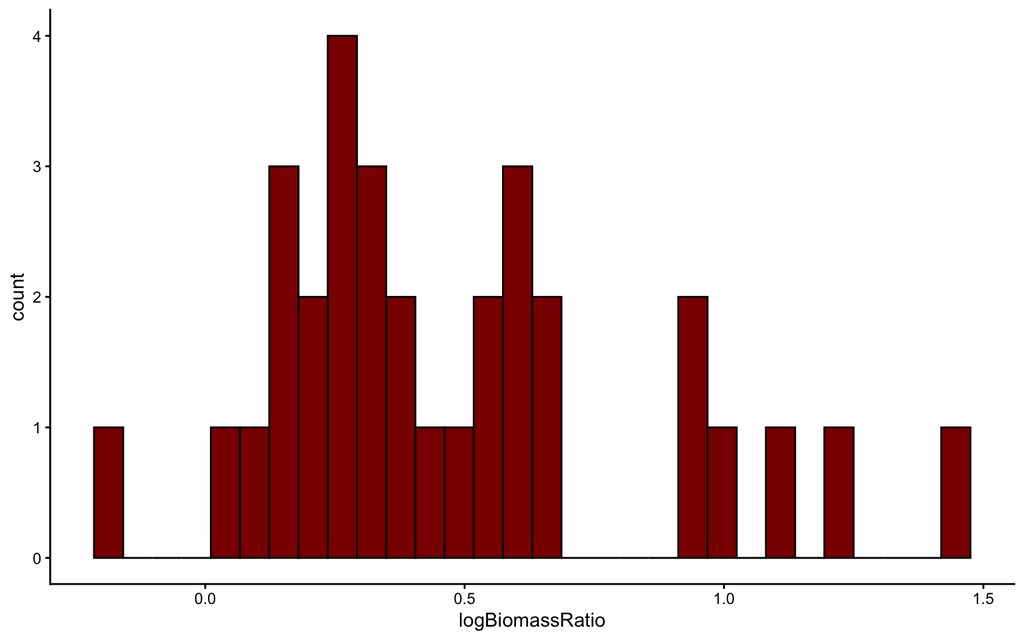

```r
ggplot(data = marine) +
  geom_histogram(mapping = aes(x = logBiomassRatio),col="black",fill="darkred")
```

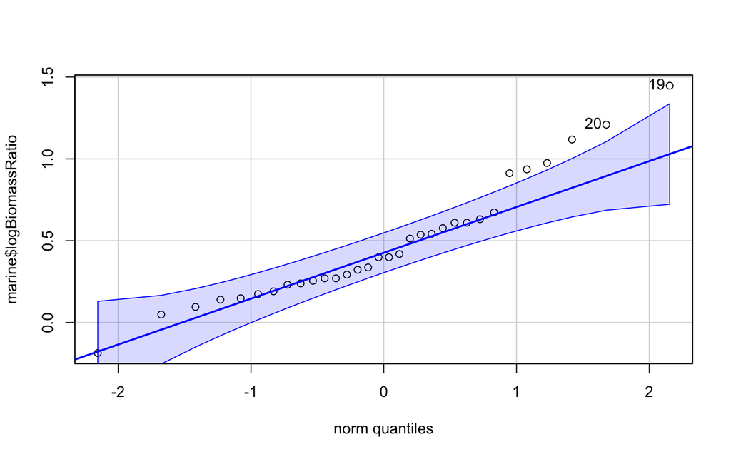

```
## [1] 19 20
```

```r
qqPlot(marine$logBiomassRatio, distribution = "norm")
```

95% confidence interval of the mean using the log-transformed data.

```r
t.test(marine$logBiomassRatio)$conf.int
```

```
## [1] 0.3470180 0.6112365
## attr(,"conf.level")
## [1] 0.95
```

Back-transform lower and upper limits of confidence interval (exp is the inverse of the log function).

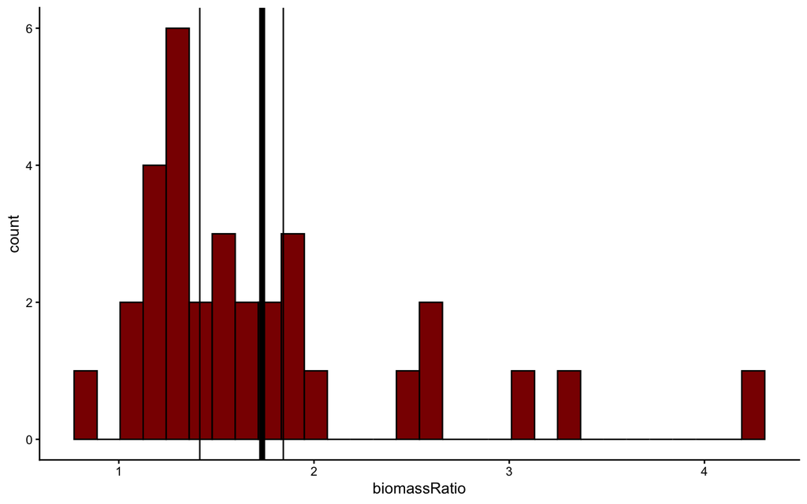

```r
conf.int = exp(t.test(marine$logBiomassRatio)$conf.int )
meanBiomassRatio = mean(marine$biomassRatio)

ggplot(data = marine) +
  geom_histogram(mapping= aes(x = biomassRatio),col="black",fill="darkred") +
  geom_vline(xintercept = conf.int)+
  geom_vline(xintercept = meanBiomassRatio,lwd=2)
```

## Non-Parametric Alternatives

We use the Wilcoxon rank-sum test (equivalent to the Mann-Whitney U-test) comparing times to mating (in hours) of starved and fed female sagebrush crickets. We also apply the permutation test to the same data.

Read and inspect data:

```r
cannibalism <- read.csv(url("http://www.zoology.ubc.ca/~schluter/WhitlockSchluter/wp-content/data/chapter13/chap13e5SagebrushCrickets.csv"))
head(cannibalism)
```

```
##   feedingStatus timeToMating
## 1       starved          1.9
## 2       starved          2.1
## 3       starved          3.8
## 4       starved          9.0
## 5       starved          9.6
## 6       starved         13.0
```

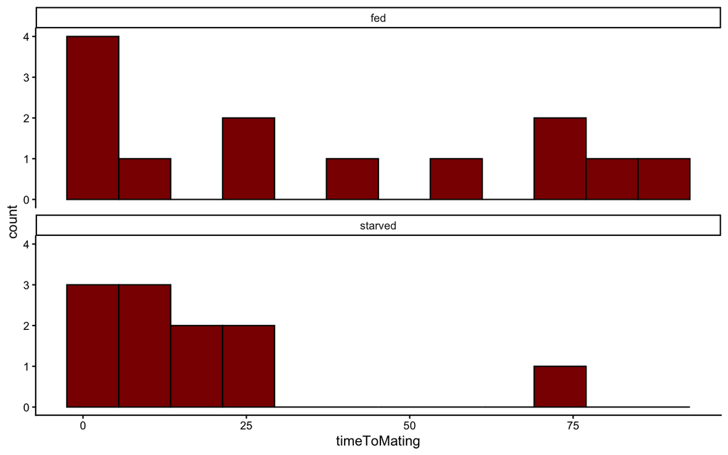

```r
ggplot(data = cannibalism) +
  geom_histogram(mapping = aes(x = timeToMating ),bins=12,color="black",fill="darkred") +
  facet_wrap( ~feedingStatus,nrow=2) +
  theme_classic()
```

We perfrom the Wilcoxon rank-sum test (equivalent to Mann-Whitney U-test)

```r
wilcox.test(timeToMating ~ feedingStatus, data = cannibalism)
```

```
##
##  Wilcoxon rank sum exact test
##
## data:  timeToMating by feedingStatus
## W = 88, p-value = 0.3607
## alternative hypothesis: true location shift is not equal to 0
```

## Permutation Test

We use a permutation test of the difference between mean time to mating of starved and fed crickets.We begin by calculating the observed difference between means (starved minus fed). The difference is -18.25734 in this data set.

```r
# tapply is another way to calcualte the means of time to mating
# for each feeding status seperatly

cricketMeans <- tapply(cannibalism$timeToMating, cannibalism$feedingStatus, mean)

cricketMeans
```

```
##      fed  starved
## 35.98462 17.72727
```

```r
diffMeans <- cricketMeans[2] - cricketMeans[1]
diffMeans
```

```
##   starved
## -18.25734
```

```r
nPerm <- 10000
set.seed(2048)
```

The following code implements aloop to permute the data many times (determined by nperm, investigate the function sample to see what it does). In the loop, i is just a counter that goes from 1 to nPerm by 1; each permuted difference is saved in the permResult.

```r
permResult <- vector() # initializes
for(i in 1:nPerm){
    # step 1: permute the times to mating
    permSample <- sample(cannibalism$timeToMating, replace = FALSE)
    # step 2: calculate difference betweeen means
    permMeans <- tapply(permSample, cannibalism$feedingStatus, mean)
    permResult[i] <- permMeans[2] - permMeans[1]
}
```

Plot null distribution based on the permuted differences.

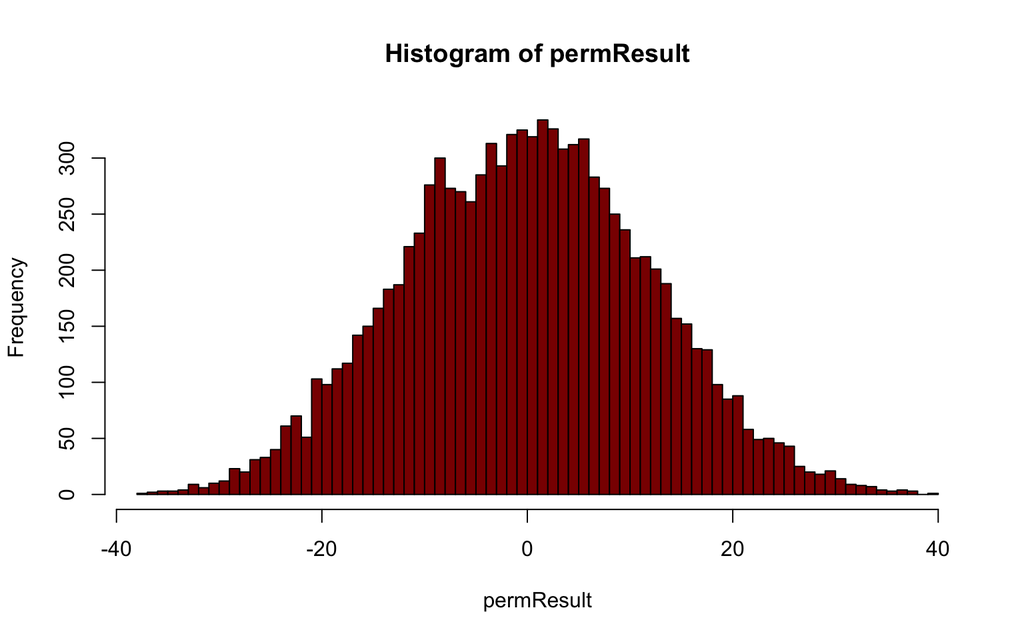

```r
hist(permResult, right = FALSE, breaks = 100,col="darkred")
```

Use the null distribution to calculate an approximate P-value. This is the twice the proportion of the permuted means that fall below the observed difference in means, diffMeans (-18.25734 in this example). The following code calculates the number of permuted means falling below diffMeans.

```r
sum(as.numeric(permResult <= diffMeans))
```

```
## [1] 657
```

These commands obtain the fraction of permuted means falling below diffMeans.

```r
sum(as.numeric(permResult <= diffMeans)) / nPerm
```

```
## [1] 0.0657
```

Finally, multiply by 2 to get the P-value for a two-sided test.

```r
2 * ( sum(as.numeric(permResult <= diffMeans)) / nPerm )
```

```
## [1] 0.1314
```

We can illustrate the permutaed differences and add the observed difference on to show the outcome of our test: the birght red colored bars indicate the proportion of permutation results that yielded a more exterme results as the on observed.

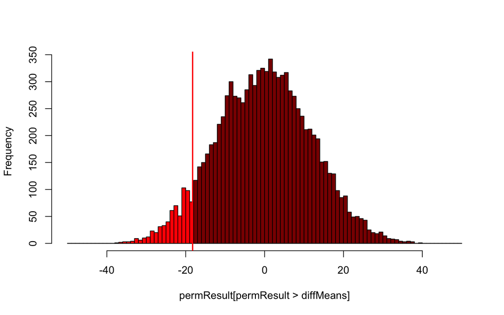

```r
hist(permResult[permResult>diffMeans],breaks=seq(-50,50,by=1),col="darkred",main="")
hist(permResult[permResult<=diffMeans],breaks=seq(-50,50,by=1),add=T,col="red")
abline(v = diffMeans,col="red",lwd=2)
```

# ANOVA

## One way ANOVA

We compare the phase shift in the circadian rhythm of melatonin production in participants given alternative light treatments.

Read and inspect the data.

```r
circadian <- read.csv(url("http://www.zoology.ubc.ca/~schluter/WhitlockSchluter/wp-content/data/chapter15/chap15e1KneesWhoSayNight.csv"))
```

Set the preferred ordering of groups in tables and graphs.

```r
circadian$treatment <- factor(circadian$treatment,
    levels = c("control", "knee", "eyes"))



meanShift <- tapply(circadian$shift, circadian$treatment, mean)
sdevShift <- tapply(circadian$shift, circadian$treatment, sd)
n         <- tapply(circadian$shift, circadian$treatment, length)
mean_SD =data.frame(mean = meanShift, std.dev = sdevShift, n = n,treatment = c("control", "knee", "eyes"))
```

We plot the data showing the raw data points as well as the mean (including error bars shwoing one standard error in each direction).

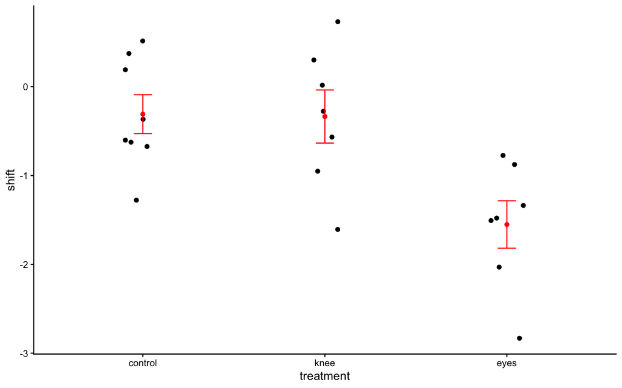

```r
ggplot(data = circadian) +
  geom_jitter(mapping = aes(x = treatment,y=shift),width=0.1) +
  geom_errorbar(data = mean_SD,mapping = aes(x = treatment,ymin=meanShift-sdevShift/sqrt(n), ymax=meanShift+sdevShift/sqrt(n)), width=.1,color="red") +
  geom_point(data = mean_SD,mapping = aes(x = treatment,y=meanShift),color="red")
```

The first step involves fitting the ANOVA model to the data using lm (“lm” stands for “linear model”, of which ANOVA is one type). Then we use the command anova to assemble the ANOVA table.

```r
circadianAnova <- lm(shift ~ treatment, data = circadian)
anova(circadianAnova)
```

```
## Analysis of Variance Table
##
## Response: shift
##           Df Sum Sq Mean Sq F value   Pr(>F)
## treatment  2 7.2245  3.6122  7.2894 0.004472 **
## Residuals 19 9.4153  0.4955
## ---
## Signif. codes:  0 '***' 0.001 '**' 0.01 '*' 0.05 '.' 0.1 ' ' 1
```

R2 indicating the fraction of variation in the response variable “explained” by treatment. This is again done in two steps. The first step calculates a bunch of useful quantities from the ANOVA model object previously created with a lm command. The second step shows the R2 value.

```r
circadianAnovaSummary <- summary(circadianAnova)
circadianAnovaSummary$r.squared
```

```
## [1] 0.4341684
```

## Two way ANOVA

Analyze data from a factorial experiment investigating the effects of herbivore presence, height above low tide, and the interaction between these factors, on abundance of a red intertidal alga using two-factor ANOVA.

Read and inspect the data.

```r
algae <- read.csv(url("http://www.zoology.ubc.ca/~schluter/WhitlockSchluter/wp-content/data/chapter18/chap18e3IntertidalAlgae.csv"))
head(algae)
```

```
##   height herbivores  sqrtArea
## 1    low      minus  9.405573
## 2    low      minus 34.467736
## 3    low      minus 46.673485
## 4    low      minus 16.642139
## 5    low      minus 24.377498
## 6    low      minus 38.350604
```

We first take a look at the data:

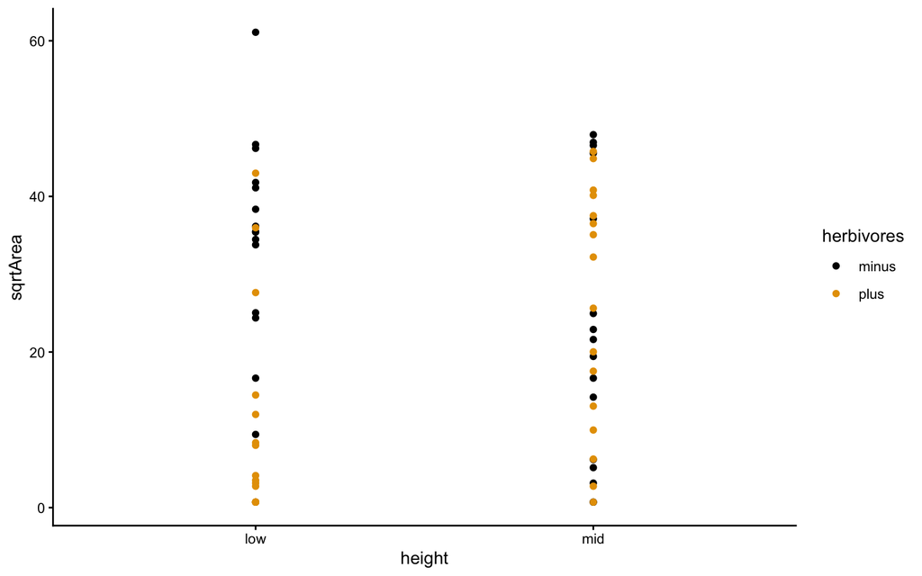

```r
ggplot(data = algae,  aes(x = height, color = herbivores, group = herbivores, y = sqrtArea)) +
  geom_point()
```

This is a mess so we next add some summary statistics of the data: the mean Area for each combination of explanatory variables.

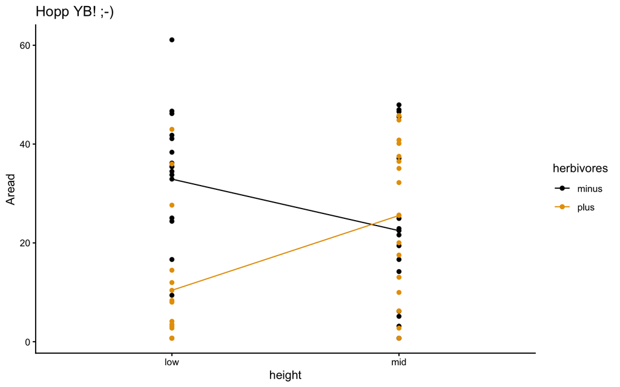

```r
ggplot(data = algae) +
  aes(x = height, color = herbivores, group = herbivores, y = sqrtArea) +
    geom_point()+
  stat_summary(fun.y = mean, geom = "point") +
  stat_summary(fun.y = mean, geom = "line")+
  labs(title="Hopp YB! ;-)",
        x ="height", y = "Aread")
```

It looks like there is some interaction between *height* and *herbivores*, but there is also quite some noise so it is difficult to tell.

Let us first fit a null model having both main effects but no interaction term. We can do this again with *lm* (*note:* conceptually a t-test, an ANOVA and linear regression are all pretty much the same thing and hence the function lm can be used in all these cases):

```r
algaeNoInteractModel <- lm(sqrtArea ~ height + herbivores, data = algae)

summary(algaeNoInteractModel)
```

```
##
## Call:
## lm(formula = sqrtArea ~ height + herbivores, data = algae)
##
## Residuals:
##     Min      1Q  Median      3Q     Max
## -28.171 -13.748  -2.235  15.433  34.576
##
## Coefficients:
##                Estimate Std. Error t value Pr(>|t|)
## (Intercept)      26.520      3.602   7.362 5.53e-10 ***
## heightmid         2.358      4.160   0.567   0.5729
## herbivoresplus   -9.722      4.160  -2.337   0.0227 *
## ---
## Signif. codes:  0 '***' 0.001 '**' 0.01 '*' 0.05 '.' 0.1 ' ' 1
##
## Residual standard error: 16.64 on 61 degrees of freedom
## Multiple R-squared:  0.0866, Adjusted R-squared:  0.05665
## F-statistic: 2.892 on 2 and 61 DF,  p-value: 0.06311
```

Now fit the full model, with interaction term included.

```r
algaeFullModel <- lm(sqrtArea ~ height * herbivores, data = algae)
```

Finally we cretea na ANOVA table that compares the two models:

```r
anova(algaeNoInteractModel, algaeFullModel)
```

```
## Analysis of Variance Table
##
## Model 1: sqrtArea ~ height + herbivores
## Model 2: sqrtArea ~ height * herbivores
##   Res.Df   RSS Df Sum of Sq      F   Pr(>F)
## 1     61 16888
## 2     60 14270  1      2617 11.003 0.001549 **
## ---
## Signif. codes:  0 '***' 0.001 '**' 0.01 '*' 0.05 '.' 0.1 ' ' 1
```

# Linear Regression

We test the null hypothesis of zero regression slope. The data are from an experiment investigating the effect of plant species diversity on the stability of plant biomass production.

Read and inspect the data.

```r
prairie <- read.csv(url("http://www.zoology.ubc.ca/~schluter/WhitlockSchluter/wp-content/data/chapter17/chap17e3PlantDiversityAndStability.csv"))
head(prairie)
```

```
##   nSpecies biomassStability
## 1        1             7.47
## 2        1             6.74
## 3        1             6.61
## 4        1             6.40
## 5        1             5.67
## 6        1             5.26
```

We perfrom a Log-transform on the varibale stability and include the new variable in the data frame. Inspect the data frame once again to make sure the function worked as intended.

```r
prairie = mutate(prairie,logStability = log(biomassStability))
head(prairie)
```

```
##   nSpecies biomassStability logStability
## 1        1             7.47     2.010895
## 2        1             6.74     1.908060
## 3        1             6.61     1.888584
## 4        1             6.40     1.856298
## 5        1             5.67     1.735189
## 6        1             5.26     1.660131
```

Scatter plot with regression line in base R:

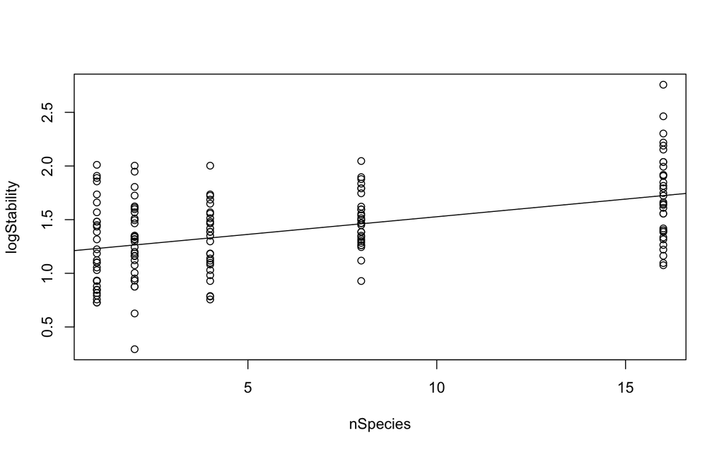

```r
plot(logStability ~ nSpecies, data = prairie)
prairieRegression <- lm(logStability ~ nSpecies, data = prairie)
abline(prairieRegression)
```

Scatter plot with regression line in ggplot:

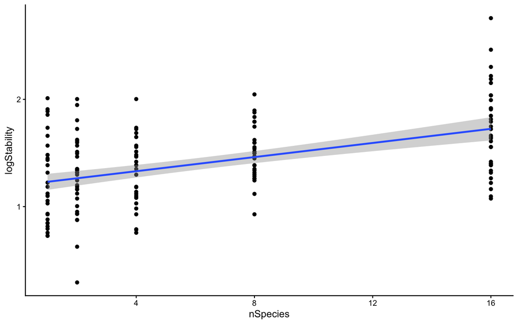

```r
ggplot(data = prairie,aes(y=logStability,x=nSpecies)) +
  geom_point()+
  geom_smooth(method = "lm")
```

```r
prairieRegression <- lm(logStability ~ nSpecies, data = prairie)
summary(prairieRegression)
```

```
##
## Call:
## lm(formula = logStability ~ nSpecies, data = prairie)
##
## Residuals:
##      Min       1Q   Median       3Q      Max
## -0.97148 -0.25984 -0.00234  0.23100  1.03237
##
## Coefficients:
##             Estimate Std. Error t value Pr(>|t|)
## (Intercept) 1.198294   0.041298  29.016  < 2e-16 ***
## nSpecies    0.032926   0.004884   6.742 2.73e-10 ***
## ---
## Signif. codes:  0 '***' 0.001 '**' 0.01 '*' 0.05 '.' 0.1 ' ' 1
##
## Residual standard error: 0.3484 on 159 degrees of freedom
## Multiple R-squared:  0.2223, Adjusted R-squared:  0.2174
## F-statistic: 45.45 on 1 and 159 DF,  p-value: 2.733e-10
```

```r
confint(prairieRegression)
```

```
##                  2.5 %     97.5 %
## (Intercept) 1.11673087 1.27985782
## nSpecies    0.02328063 0.04257117
```

Finally, we check our modelling assumptions with a QQ plot of the residuals as well as a Tukey-Anscombe plot:

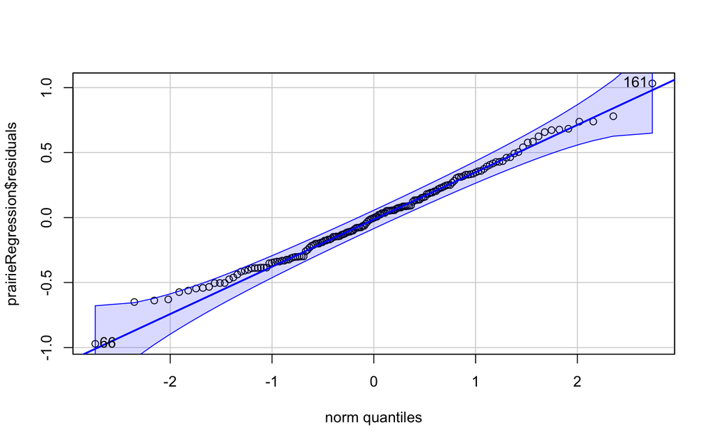

```
## [1] 161  66
```

```r
qqPlot(prairieRegression$residuals,dist="norm")
```

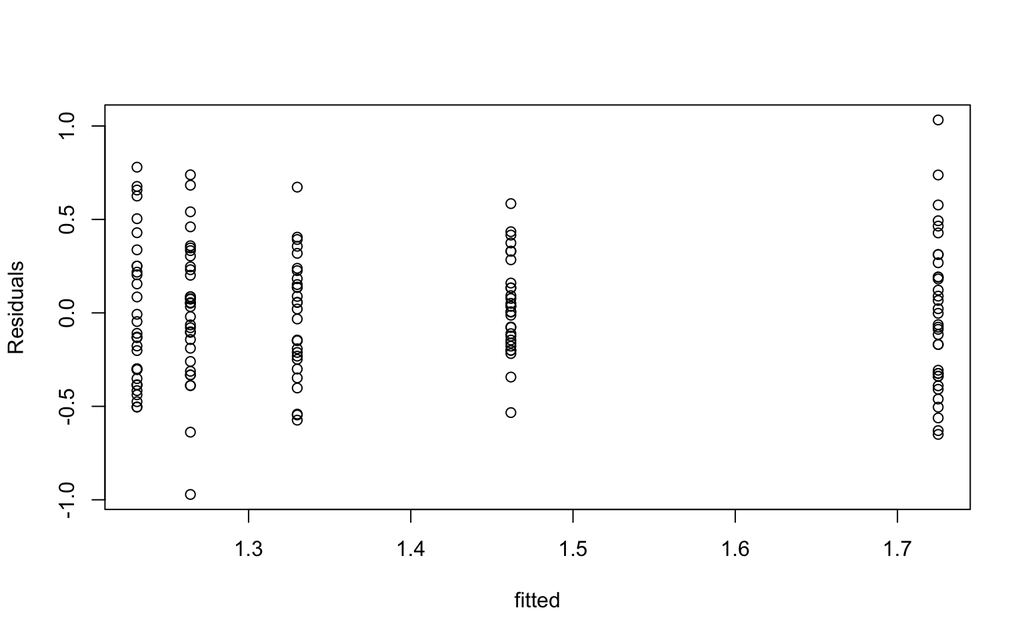

```r
plot(prairieRegression$fitted.values,prairieRegression$residuals,xlab="fitted",ylab="Residuals")
```

# Additional notes to the course slides

## Law of total probability

Assume that ${B_{i}, i=1,2,3,\ldots }$ is a set of pairwise disjoint events whose union is the entire sample space (that is, every possible event that can happen is covered by exactly one of the $B_i$s).

As an example: consider rolling a six-sided die. Then the event $B_i (i = 1, ..., 6)$ is the event that you roll the number $i$. All events are disjoint and together they cover everything that can happen.

For any event $A$ we can then write

$$P(A) = \sum _{i}P(A \cap
B_{i})$$

or, equivalently,

$$P(A) = \sum_{i} P(A \mid
B_{i})P(B_{i}).$$

This figure is helpful for understanding what is going on here:

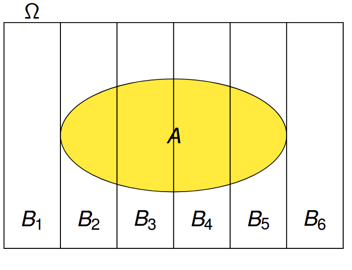

Illustration of the law of total probability

Example:

We roll two dice. We want to know the probaility that the first roll has a smaller outcome than the second roll.

We call the events $B_i, i = 1, ..., 6$ the event that the frist roll shows $i$ dots. So $B_2$ is the event that you roll a 2 with the first roll. (Think about why this satisfies the conditons for the events $B_i$ stated in the law of total probaility.)

$$P(A) = \sum_{i} P(A \mid
B_{i})P(B_{i}).$$

If you roll a $i$ with the first die, there are 6-$i$ possible outcomes for the second roll that are larger than $i$. This means: $P(A \mid B_{1}) = 5/6$ $P(A \mid B_{2}) = 4/6$ $P(A \mid B_{3}) = 3/6$ $P(A \mid B_{4}) = 2/6$ $P(A \mid B_{5}) = 1/6$ $P(A \mid B_{6}) = 0$

and furthermore

$P(B_i) = 1/6$ for each $i$.

Then

$P(A) = 5/6 * 1/6 + 4/6 * 1/6$ $+3/6 * 1/6 + 2/6*1/6 + 1/6 *1/6 + 0 *1/6$

$= 0.417.$

Let us test this with a small R simulation:

```r
# We do 10000 die rolls for each die:
die.1 = sample.int(6, size = 10000,replace=T)
die.2 = sample.int(6, size = 10000,replace=T)

# calcualte the proportion of times die 2 is larger than die 1
sum(die.2>die.1)/10000
```

```
## [1] 0.4129
```

# Exercises

Exercises can be found [here (html)](https://s-peischl.github.io/StatForBioFS22/Exercises_web.html) or [here (pdf)](https://s-peischl.github.io/StatForBioFS22/Exercises_web.pdf)

Solutions to the exercises will be posted [here](https://s-peischl.github.io/StatForBioFS22/Solutions_web.html) each week after the exercise session.